# 8TH SEPTEMBER ASSIGNMENT

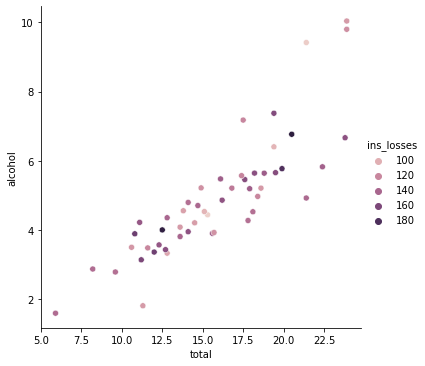

```python
sns.relplot(x="total",y="alcohol",data=df,hue="ins_losses")
```

inference: majority of the users tend to fall in the category of moderate alcohol usage and moderate accident from total number and they also have low losses

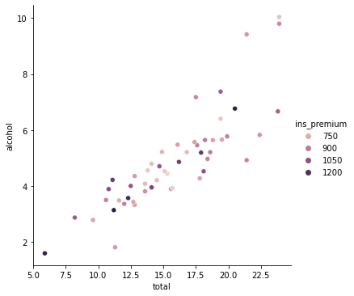

```python
sns.relplot(x="total",y="alcohol",data=df,hue="ins_premium")
```

inference: majority of users whose premium is low are moderate to highly alcoholic and account to a large number of accidents

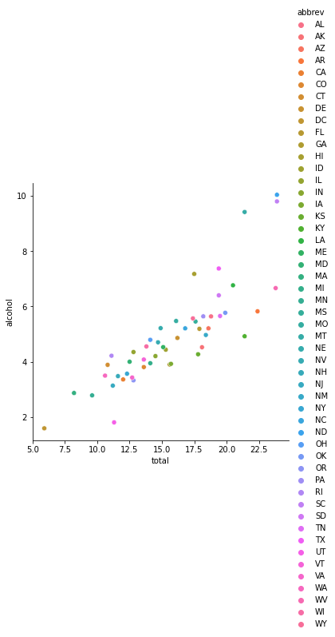

```python
sns.relplot(x="total",y="alcohol",data=df,hue="abbrev")
```

[figure not shown]

```python
sns.barplot(data=df,x="total",y="speeding",hue="ins_premium")
```

infernce: from the graph we could conclude that majority of users who pay low premium are rash drivers and tend to account higher number of accidents

[figure not shown]

```python
sns.barplot(data=df,x="total",y="speeding",hue="no_previous")
```

inference: from the graph we could infer that very few people with no previous accidents tend to cause accidents due to speeding

[figure not shown]

```python
sns.barplot(data=df,x="total",y="alcohol",hue="no_previous")
```

inference: from the graph we could conclude that a good number of people with no previous records end up in crashes due to alcohol

[figure not shown]

```python
sns.barplot(data=df,x="alcohol",y="speeding",hue="ins_losses")
```

inference: from the graph we could understand that a good number of people end up in a mix of alcohol and speeding and end up with him amount of losses

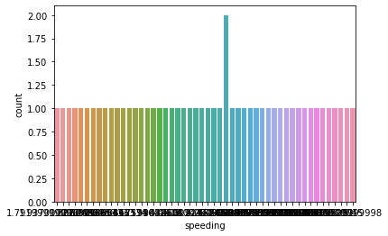

```python
sns.countplot(x="speeding",data=df)
```

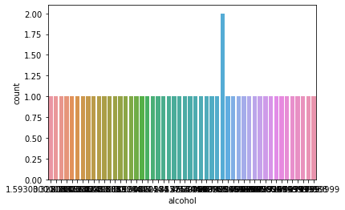

```python
sns.countplot(x="alcohol",data=df)
```

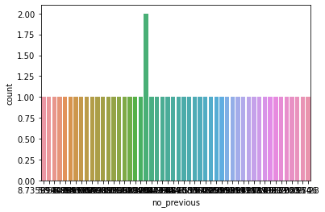

```python
sns.countplot(x="no_previous",data=df)
```

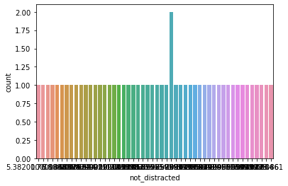

```python
sns.countplot(x="not_distracted",data=df)
```

inference: a moderately good number of people end up in accidents even without distraction

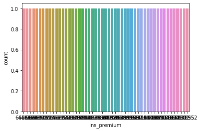

```python
sns.countplot(x="ins_premium",data=df)
```

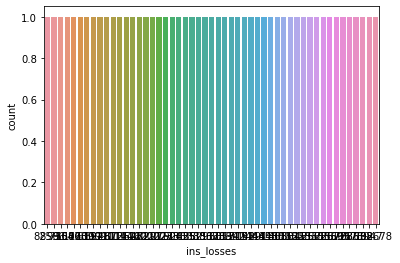

```python
sns.countplot(x="ins_losses",data=df)
```

inference: the count is evenly distributed in case of increasing premium and losses

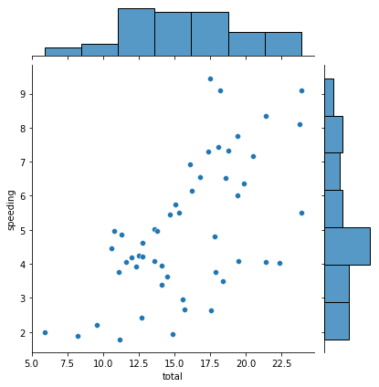

```python
sns.jointplot(x="total",y="speeding",data=df)
```

inference: from the graph there is a linear conncetion between speeding and total cases yet it is more common that a lot of people fall from the range of 12.5 to 20 in accident cases and 4 to 8 speeding cases

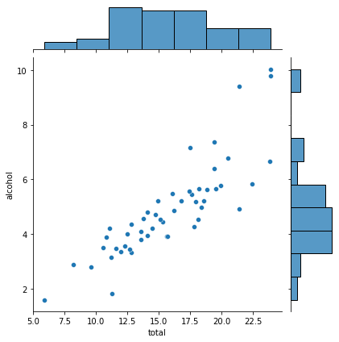

```python
sns.jointplot(x="total",y="alcohol",data=df)
```

inference: majority lies in the region of 4-6 alcohol and 10-20 total

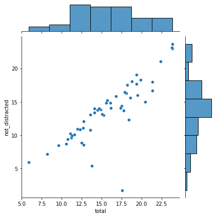

```python
sns.jointplot(x="total",y="not_distracted",data=df)
```

inference: as the total nuber of cases increase the the number of undistracted people ending in accudents also increase lineaarly

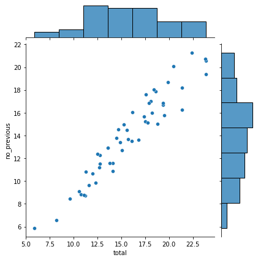

```python
sns.jointplot(x="total",y="no_previous",data=df)
```

inference: from the graph we could understand that the number of people with no previous records ending in accidents also increase with an increase in number of total accidents

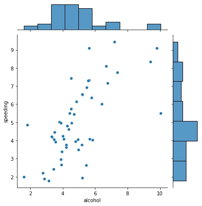

```python
sns.jointplot(x="alcohol",y="speeding",data=df)
```

inference: we could undrstand that with alcohol people end up causing crashes even at moderate speeds without speeding itself

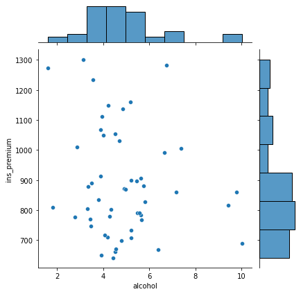

```python
sns.jointplot(x="alcohol",y="ins_premium",data=df)
```

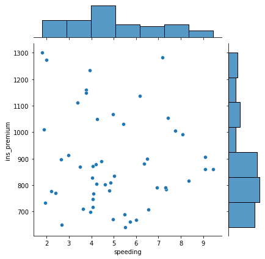

```python
sns.jointplot(x="speeding",y="ins_premium",data=df)
```

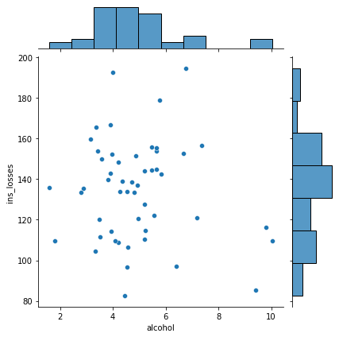

```python
sns.jointplot(x="alcohol",y="ins_losses",data=df)
```

inference: majority fall in the group of people where the number of people with alcohol usage and ins losses is in moderate number

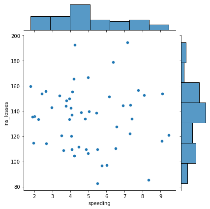

```python
sns.jointplot(x="speeding",y="ins_losses",data=df)
```

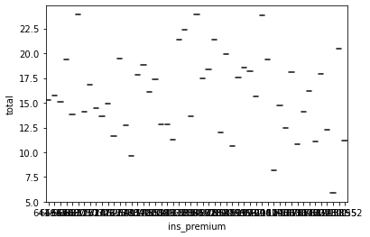

```python
sns.boxplot(x="ins_premium",y="total",data=df)
```

inference: the data seems to be insufficient to assess

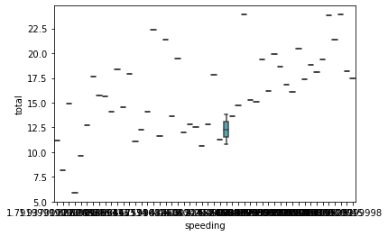

```python
sns.boxplot(x="speeding",y="total",data=df)
```

inference: as the number of speeding candidates increase there is a significant increase in the total number of accidents

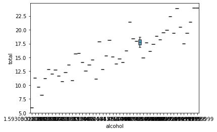

```python
sns.boxplot(x="alcohol",y="total",data=df)
```

inference: as the number of alcoholic candidates increase there is a significant increase in the total number of accidents

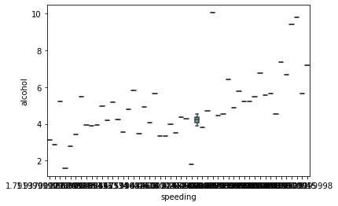

```python
sns.boxplot(x="speeding",y="alcohol",data=df)
```

inference: majority of people tend to cause accidents at all speeds when the number of alcoholics is moderate but at high speeds we could see a clear influence of high alcohol usage

```python
corr=df.corr()
corr
```

|  | total | speeding | alcohol | not_distracted | no_previous | ins_premium | ins_losses |
| --- | --- | --- | --- | --- | --- | --- | --- |
| total | 1.000000 | 0.611548 | 0.852613 | 0.827560 | 0.956179 | -0.199702 | -0.036011 |
| speeding | 0.611548 | 1.000000 | 0.669719 | 0.588010 | 0.571976 | -0.077675 | -0.065928 |
| alcohol | 0.852613 | 0.669719 | 1.000000 | 0.732816 | 0.783520 | -0.170612 | -0.112547 |
| not_distracted | 0.827560 | 0.588010 | 0.732816 | 1.000000 | 0.747307 | -0.174856 | -0.075970 |
| no_previous | 0.956179 | 0.571976 | 0.783520 | 0.747307 | 1.000000 | -0.156895 | -0.006359 |
| ins_premium | -0.199702 | -0.077675 | -0.170612 | -0.174856 | -0.156895 | 1.000000 | 0.623116 |
| ins_losses | -0.036011 | -0.065928 | -0.112547 | -0.075970 | -0.006359 | 0.623116 | 1.000000 |

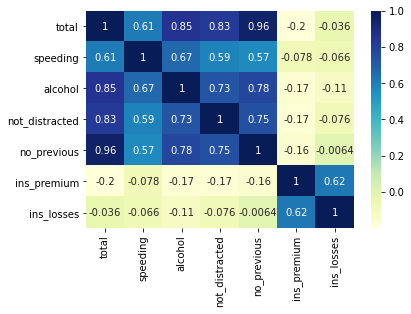

```python
sns.heatmap(corr,annot=True,cmap="YlGnBu")
```